# Crude Oil Autocorrelation

FIN 3380

## Set working directory

```r
setwd("C:/Users/siche/Documents/teaching/Introduction to Financial Data Analysis/L5")
library(dplyr)
```

## Step 1. Download data from St. Louis Fed Website

#### “https://fred.stlouisfed.org/series/DCcrudeWTICO”

```r
crude = read.csv("crude_oil.csv")
head(crude)
```

```
##         DATE MCOILWTICO
## 1 1986-01-01      22.93
## 2 1986-02-01      15.46
## 3 1986-03-01      12.61
## 4 1986-04-01      12.84
## 5 1986-05-01      15.38
## 6 1986-06-01      13.43
```

```r
class(crude$DATE)
```

```
## [1] "factor"
```

```r
class(crude$MCOILWTICO)
```

```
## [1] "numeric"
```

```r
# change to tibble type data frame
crude = as_tibble(crude)
head(crude)
```

```
## # A tibble: 6 x 2
##   DATE       MCOILWTICO
##   <fct>           <dbl>
## 1 1986-01-01       22.9
## 2 1986-02-01       15.5
## 3 1986-03-01       12.6
## 4 1986-04-01       12.8
## 5 1986-05-01       15.4
## 6 1986-06-01       13.4
```

```r
# change data type
crude$DATE = as.Date(crude$DATE)
colnames(crude) = c("date","price")
head(crude)
```

```
## # A tibble: 6 x 2
##   date       price
##   <date>     <dbl>
## 1 1986-01-01  22.9
## 2 1986-02-01  15.5
## 3 1986-03-01  12.6
## 4 1986-04-01  12.8
## 5 1986-05-01  15.4
## 6 1986-06-01  13.4
```

```r
# calculate returns of crude
crude = crude %>% arrange(date) %>%
  mutate(ret = log(price)-log(dplyr::lag(price,1))) %>%
  na.omit()
head(crude)
```

```
## # A tibble: 6 x 3
##   date       price     ret
##   <date>     <dbl>   <dbl>
## 1 1986-02-01  15.5 -0.394
## 2 1986-03-01  12.6 -0.204
## 3 1986-04-01  12.8  0.0181
## 4 1986-05-01  15.4  0.181
## 5 1986-06-01  13.4 -0.136
## 6 1986-07-01  11.6 -0.147
```

## Step 2. Visualise the returns and acf function

#### Plot multiple charts using par(mfcol = c(a,b)), where a and b are rows and columns in multiple chart setting.

```r
par(mfcol=c(2,1),size="A4")
```

```r
plot(crude$ret,xlab='month',ylab='returns',type='l',
     main='(a): Simple returns')
# command to obtain sample ACF of the data
crude.acf = acf(crude$ret,lag=24,plot=F)
head(crude.acf$lag)
```

```
## [1] 0 1 2 3 4 5
```

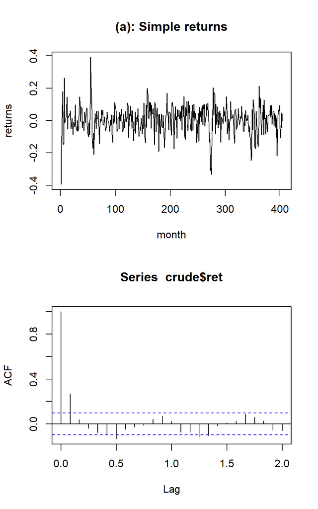

```r
# amend the lags to months instead of years
crude.acf$lag = crude.acf$lag/12
plot(crude.acf)
```

#### Figure gives the sample ACF of the series.

#### The two horizontal dashed lines of the ACF plot are the two standard error limits, that is, $±2/\sqrt{T}$

#### The ACF plot starts with $\rho_0=1$

#### The plot clearly shows that the lag-1 ACF is significantly different from 0 at the 5% level.

#### This means, an increase in the oil price last month is more likely to be followed by a further increase this month.

## Step 3. Calculate the t stats that is used to test individual $\rho_k$ is not zero.

#### Here, we calcuate the lag-1 tstat

```r
crude.acf$acf
```

```
## , , 1
##
##               [,1]
##  [1,]  1.000000000
##  [2,]  0.268552364
##  [3,]  0.038161784
##  [4,] -0.038453191
##  [5,] -0.077600773
##  [6,] -0.087213875
##  [7,] -0.133745969
##  [8,] -0.047613995
##  [9,] -0.025199498
## [10,] -0.012939795
## [11,]  0.040582351
## [12,]  0.071169733
## [13,]  0.023375186
## [14,] -0.072910988
## [15,] -0.074811634
## [16,] -0.119152918
## [17,] -0.104329719
## [18,] -0.016373110
## [19,]  0.008406677
## [20,]  0.027679414
## [21,]  0.086313548
## [22,]  0.057870145
## [23,]  0.025484738
## [24,] -0.055493164
## [25,] -0.058132240
```

```r
tstat = crude.acf$acf[2]*sqrt(crude.acf$n.used)
tstat
```

```
## [1] 5.397836
```

## Step 4. Joint test for the serial autocorrelation

```r
Box.test(crude$ret,lag=12,type="Ljung")
```

```
##
##  Box-Ljung test
##
## data:  crude$ret
## X-squared = 47.818, df = 12, p-value = 3.362e-06
```

#### The p value is very small, rejecting the null hypothesis $H_0: \rho_1 =\rho_2=...\rho_{12}=0$

```r
save(crude,file="crude.RData")
```

## Step 5. Use auto.arima() function to fit the crude oil return

```r
load("crude.RData")
library(forecast)
rst = auto.arima(crude$ret)
rst
```

```
## Series: crude$ret
## ARIMA(1,0,0) with zero mean
##
## Coefficients:
##          ar1
##       0.2832
## s.e.  0.0490
##
## sigma^2 estimated as 0.006966:  log likelihood=430.49
## AIC=-856.98   AICc=-856.95   BIC=-848.98
```

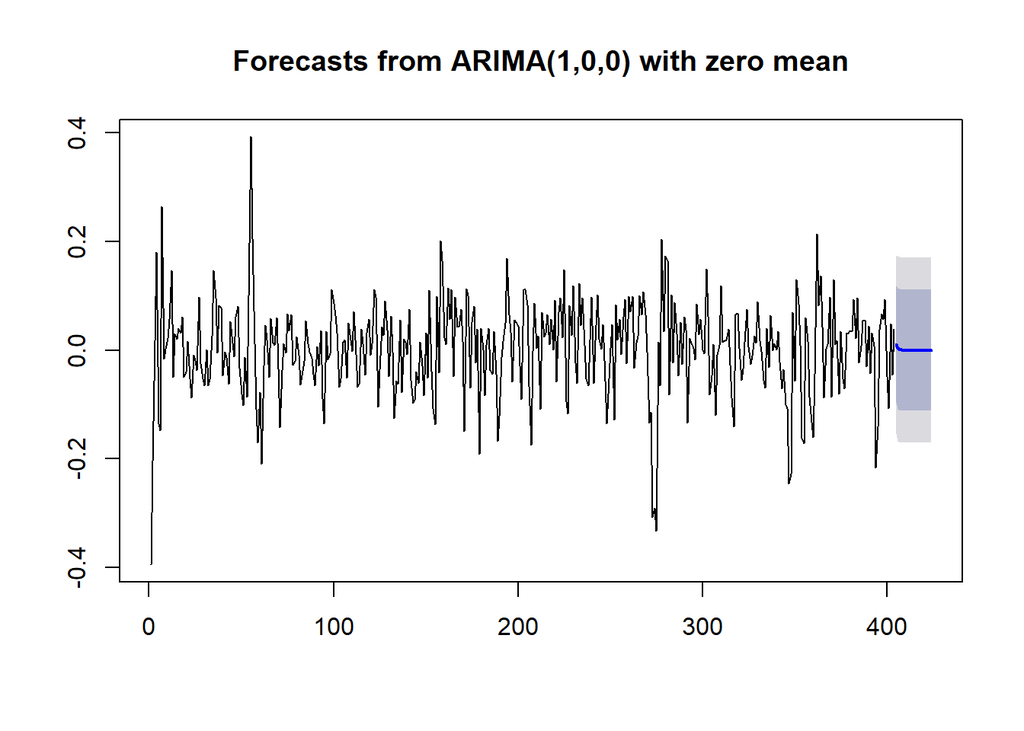

```r
plot(forecast(rst,h=20))
```

## Step 6. Use arima to select the model by ourself.

#### 1. Plot the data and identify any unusual observations.

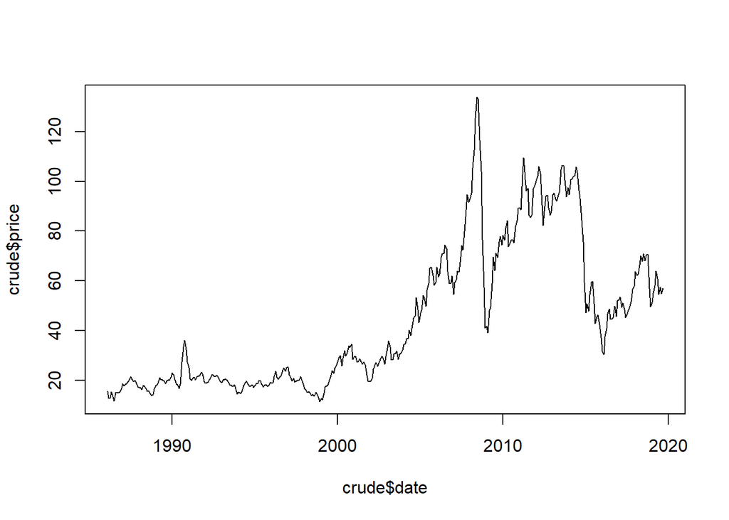

```r
plot(crude$price~crude$date,type='l')
```

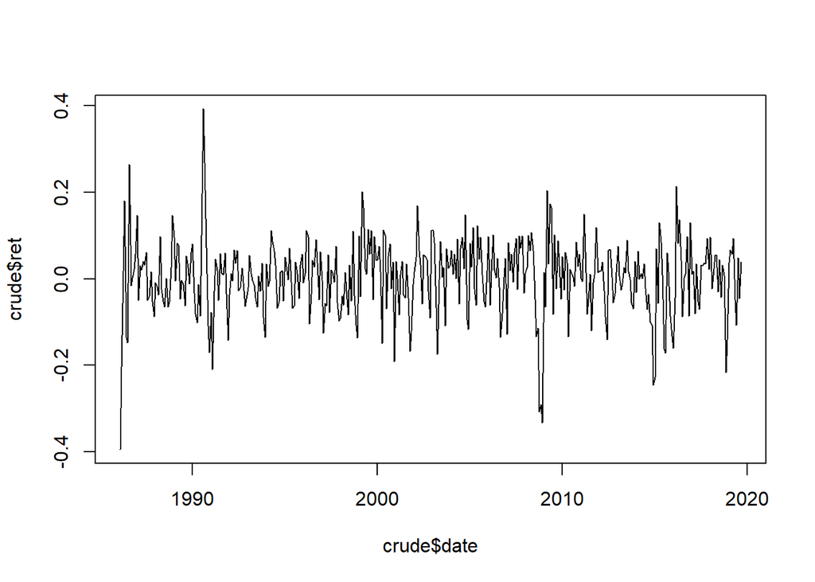

```r
plot(crude$ret~crude$date,type='l')
```

#### 2. If the data are non-stationary, take first differences of the data until the data are stationary.

```r
library(fUnitRoots)
adf = adfTest(crude$price)
adf
```

```
##
## Title:
##  Augmented Dickey-Fuller Test
##
## Test Results:
##   PARAMETER:
##     Lag Order: 1
##   STATISTIC:
##     Dickey-Fuller: -0.9537
##   P VALUE:
##     0.3124
##
## Description:
##  Mon Nov 25 08:03:20 2019 by user: siche
```

```r
adf = adfTest(crude$ret)
adf
```

```
##
## Title:
##  Augmented Dickey-Fuller Test
##
## Test Results:
##   PARAMETER:
##     Lag Order: 1
##   STATISTIC:
##     Dickey-Fuller: -12.9491
##   P VALUE:
##     0.01
##
## Description:
##  Mon Nov 25 08:03:20 2019 by user: siche
```

##### Can’t reject unit root in price

##### Unit root in return is rejected

#### 3. Examine the ACF/PACF: Is an ARIMA(p,d,0) or ARIMA(0,d,q) model appropriate?

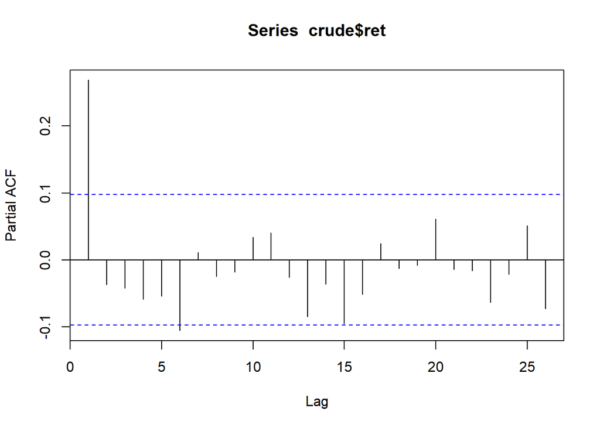

```r
pacf(crude$ret)
```

##### Indicating a AR(1)

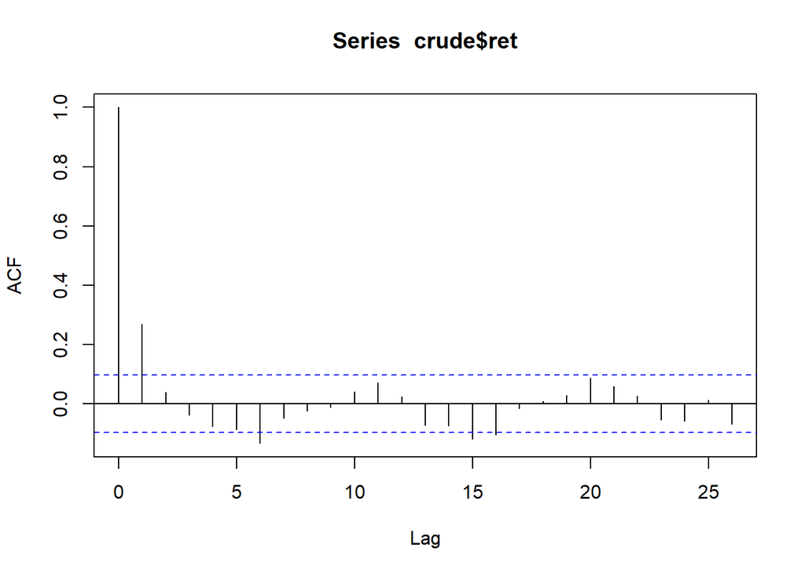

```r
acf(crude$ret)
```

#### 4. Try your chosen model(s), and use the AICs to search for a better model.

##### Arima() from library(forecast)

```r
all.model = NULL
for (p in 0:1){
  for (q in 0:2){
    ic = Arima(crude$ret,order = c(p,0,q))$aic
    model = c(p,q,ic)
    all.model=rbind(all.model,model)
  }
}
head(all.model)
```

```
##       [,1] [,2]      [,3]
## model    0    0 -825.1994
## model    0    1 -854.1934
## model    0    2 -853.6388
## model    1    0 -855.0924
## model    1    1 -853.4485
## model    1    2 -851.6386
```

```r
all.model = as.data.frame(all.model)
colnames(all.model)=c("p","q","aic")
which(all.model$aic == min(all.model$aic))
```

```
## [1] 4
```

```r
all.model[4,]
```

```
##         p q       aic
## model.3 1 0 -855.0924
```

#### Make a forecast

```r
final.model = Arima(crude$ret,order = c(1,0,0))
predict(final.model,5)
```

```
## $pred
## Time Series:
## Start = 405
## End = 409
## Frequency = 1
## [1] 0.012176495 0.004794652 0.002708812 0.002119430 0.001952892
##
## $se
## Time Series:
## Start = 405
## End = 409
## Frequency = 1
## [1] 0.08355347 0.08682497 0.08708087 0.08710127 0.08710290
```

```r
forecast(final.model)
```

```
##     Point Forecast       Lo 80     Hi 80      Lo 95     Hi 95
## 405    0.012176495 -0.09490158 0.1192546 -0.1515853 0.1759383
## 406    0.004794652 -0.10647602 0.1160653 -0.1653792 0.1749685
## 407    0.002708812 -0.10888981 0.1143074 -0.1679666 0.1733842
## 408    0.002119430 -0.10950534 0.1137442 -0.1685959 0.1728348
## 409    0.001952892 -0.10967397 0.1135797 -0.1687657 0.1726714
## 410    0.001905834 -0.10972119 0.1135329 -0.1688130 0.1726246
## 411    0.001892537 -0.10973450 0.1135196 -0.1688263 0.1726114
## 412    0.001888780 -0.10973826 0.1135158 -0.1688300 0.1726076
## 413    0.001887719 -0.10973932 0.1135148 -0.1688311 0.1726065
## 414    0.001887419 -0.10973962 0.1135145 -0.1688314 0.1726062
```

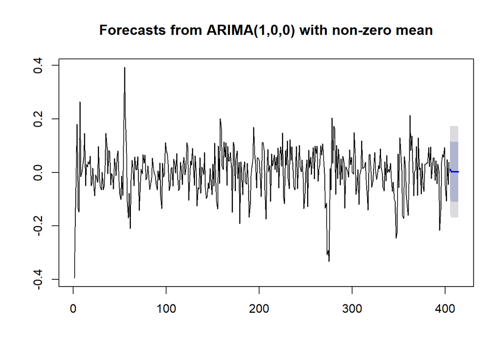

```r
plot(forecast(final.model))
```